# Gross Domestic Product data layer preparation

## Calculate annual growth rate

The annual GDP growth rate is calculated by comparing every year’s GDP total to the average of the previous 3 years.

I also add in the four offshore regions to the final data layer. The OHI toolbox needs all regions in each data layer. Since this data isn’t relevant offshore, we assign NA values to them.

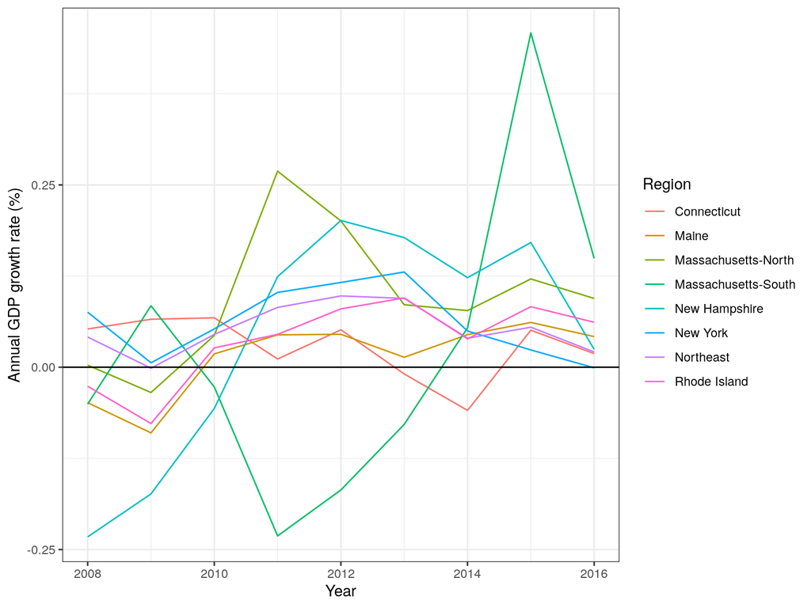

```r
other_rgns <- data.frame(year     = rep(2005:2015, each = 4),
                         rgn_id   = c(1,2,3,4),
                         rgn_name = c("Offshore", "Georges Bank", "Gulf of Maine", "Mid-Atlantic Bight"),
                         gdp_growth_rate = NA)

gdp <- gdp_data_clean %>%
  arrange(year) %>%
  group_by(rgn_id) %>%
  mutate(gdp_avg_3yr = rollapply(rgn_gdp, 3, FUN = mean, align = "right", na.rm = F, partial = T), #calculate the mean for three years
         gdp_prev_3yr = lag(gdp_avg_3yr, n = 1), #create a new column that aligns the avg wages from previous three years with the year with which we're comparing.
         gdp_growth_rate = ifelse(year %in% c(2005:2007), NA, (rgn_gdp/gdp_prev_3yr)-1)) %>% #assign NA to the first three years in the time series because there is not enough data to calculate this rate. 2007 growth rate *should* be compared to average of 2004-2006.
  write_csv("int/coastal_gdp_data.csv") %>%
  select(year, rgn_id, rgn_name, gdp_growth_rate) %>%
  ungroup() %>%
  rbind(other_rgns)

write.csv(gdp, file.path(dir_calc, "layers/eco_coast_gdp.csv"))

ggplot(gdp%>%filter(!is.na(gdp_growth_rate)), aes(x = year, y = gdp_growth_rate, color = rgn_name)) +
    geom_line() +
    labs(y = "Annual GDP growth rate (%)",
         x = "Year",
         color = "Region") +
    geom_hline(yintercept = 0) +
    theme_bw()
```

## References

National Ocean Economics Program. Ocean Economic Data by Sector & Industry., ONLINE. 2012. Available: http://www.OceanEconomics.org/Market/oceanEcon.asp [3 October 2017]